# Assignment - Week 07

Yara Roth

2026-04-17

# Setup

```r
suppressPackageStartupMessages({
  library(motifmatchr)
  library(MotifDb)
  library(universalmotif)
  library(ggplot2)
  library(sechm)
  library(limma)
  library(betterChromVAR)
  library(epiwraps)
  library(AnnotationHub)
  library(memes)
  library(ensembldb)
  library(magick)
  library(BSgenome.Mmusculus.UCSC.mm10)
})
```

```
## See system.file("LICENSE", package="MotifDb") for use restrictions.
```

```r
library(rstudioapi)
setwd(dirname(rstudioapi::getActiveDocumentContext()$path))
dir.create("data")
```

# Part I

To look at the accessability of the SP1 TF motif we will do the following: 1. Generate NF and mono-nucleosome tracks from ATAC-seq data  
2. Retrieve TF motif  
3. Find motif sites in genome  
4. Look at ATAC signals around the motif occurences

## Downloading ATAC-seq data from Chr19

```r
download.file("https://ethz-ins.org/content/w7/atac.chr19.bam", "data/atac.chr19.bam", mode="wb")
download.file("https://ethz-ins.org/content/w7/atac.chr19.bam.bai", "data/atac.chr19.bam.bai", mode="wb")
```

## Preparing tracks

```r
bam <- "data/atac.chr19.bam"

# create track to look at insertion profiles of nucleosome-free fragment
epiwraps::bam2bw(bam, output_bw = "data/NF_cuts.bw", paired=TRUE, binWidth=1L, type="ends", minFragLength=30,
       maxFragLength=120, trim=4L, extend=3L, forceSeqlevelsStyle = "Ensembl")
```

```
## Reading in signal...
```

```
## Writing bigwig...
```

```r
# create track using the centers of mono-nucleosome fragments
bam2bw(bam, output_bw = "data/mono_centers.bw", paired=TRUE, binWidth=5L, minFragLength=140, trim=4L,
       maxFragLength=220, type="center", extend=10L, forceSeqlevelsStyle = "Ensembl")
```

```
## Reading in signal...
## Writing bigwig...
```

## Obtaining sites with a SP1 or CTCF motif

I chose to make the analysis for both CTCF and SP1, which allows to compare the footprints of both.

```r
# we will first start by retrieving the SP1 TF motifs from the MotifDb database

motif_sp1 <- MotifDb::query(MotifDb, c("SP1","Mus"))[[1]]
motif2_sp1 <- convert_motifs(motif_sp1, class="TFBSTools-PFMatrix")
```

```
## Note: motif [motif] has an empty nsites slot, using 100.
```

```r
motif_ctcf <- MotifDb::query(MotifDb, c("CTCF","Mus"))[[1]]
motif2_ctcf <- convert_motifs(motif_ctcf, class="TFBSTools-PFMatrix")
```

```
## Note: motif [motif] has an empty nsites slot, using 100.
```

```r
# retrieving latest mouse genome
ah <- AnnotationHub()

query_results <- AnnotationHub::query(ah, c("Mus Musculus","TwoBitFile","101","GRCm38","primary_assembly"))
head(query_results)
```

```
## AnnotationHub with 3 records
## # snapshotDate(): 2025-10-29
## # $dataprovider: Ensembl
## # $species: mus musculus
## # $rdataclass: TwoBitFile
## # additional mcols(): taxonomyid, genome, description,
## #   coordinate_1_based, maintainer, rdatadateadded, preparerclass, tags,
## #   rdatapath, sourceurl, sourcetype
## # retrieve records with, e.g., 'object[["AH84785"]]'
##
##             title
##   AH84785 | Mus_musculus.GRCm38.dna.primary_assembly.2bit
##   AH84786 | Mus_musculus.GRCm38.dna_rm.primary_assembly.2bit
##   AH84787 | Mus_musculus.GRCm38.dna_sm.primary_assembly.2bit
```

```r
genome_m <- ah[["AH84785"]]
```

```
## loading from cache
```

```r
chr19 <- import(genome_m)["19"]
```

```r
# find SP1 motif matches across Chr19
moi_sp1 <- motifmatchr::matchMotifs(motif2_sp1, chr19, out="positions", p.cutoff=1e-5)[[1]]
moi_sp1 <- as(setNames(moi_sp1,names(chr19)), "GRanges")

moi_ctcf <- motifmatchr::matchMotifs(motif2_ctcf, chr19, out="positions", p.cutoff=1e-5)[[1]]
moi_ctcf <- as(setNames(moi_ctcf,names(chr19)), "GRanges")
```

## Plotting ATAC-signals around motifs

### ATAC signals for CTCF motifs

```r
tracks <- list.files("data/", pattern="bw$", full.names=TRUE)
names(tracks) <- gsub("\\.bw","",basename(tracks))

sm_ctcf <- signal2Matrix(tracks, moi_ctcf, w=5, extend=300)
```

```
## Reading data//mono_centers.bw
```

```
## Reading data//NF_cuts.bw
```

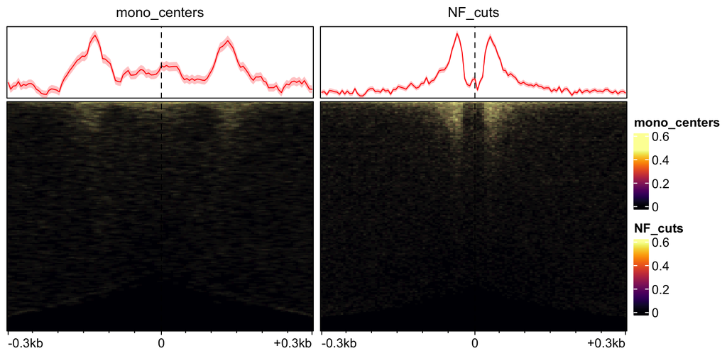

```r
plotEnrichedHeatmaps(sm_ctcf, trim=0.95, multiScale = TRUE, axis_name = "0")
```

The signals of the nucleosome-free fragments shows a very low coverage in the very center and two large peaks adjacent. The low signal in the center corresponds to the region where the TF binds (prevents TN5 insertion) = TF footprint. The two adjecent peaks indicate that the chromatin is accessbile there.  
When looking at the signals of the mono-nucleosome fragments, we see two peaks adjecent to the motifs center. This corresponds to the nucleosomes that get pushed to the side, when the TF binds.

### ATAC signals around SP1 signals

```r
tracks <- list.files("data/", pattern="bw$", full.names=TRUE)
names(tracks) <- gsub("\\.bw","",basename(tracks))

sm_sp1 <- signal2Matrix(tracks, moi_sp1, w=5, extend=300)
```

```
## Reading data//mono_centers.bw
```

```
## Reading data//NF_cuts.bw
```

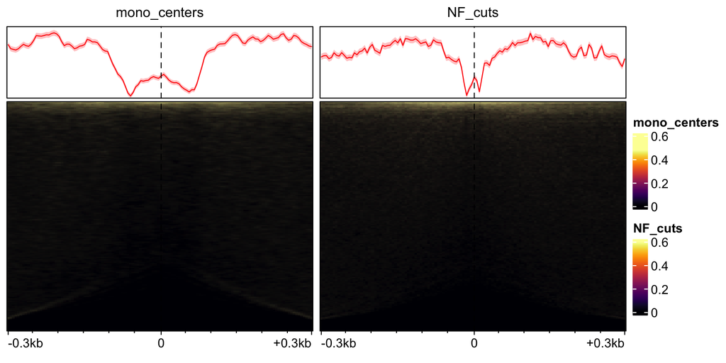

```r
plotEnrichedHeatmaps(sm_sp1, trim=0.95, multiScale = TRUE, axis_name = "0")
```

The signals of the nucleosome-free fragments show low coverage in the center, probably corresponding to the SP1 binding site. Interestingly, the signal for the nucleosome-free fragments shows a gradual, continuous increase towards the side (unlike CTCF, which displayed two sharp peaks adjecent to the center). For the mono-nucleosome fragments, we also see a rather gradual, continuous increase outwards. This indicates that SP1 has a weaker effect on nucleosome positioning and that the TF has a less pronounced footprint (compared to CTCF).

# Part 2

To identify motifs that are differentially acessible in between males and females in stressed vs control we do the following:  
1. Annotate peaks with GC bias  
2. Get a list of motifs  
3. Scan the ATAC seq peaks for motif matches  
4. Calculate the motif accessability deviations  
5. Perform differential analysis

## Downloading ATAC data from stressed brain

I decided to work with the whole data (stressed and controlled).

```r
download.file("https://ethz-ins.org/content/mouse_mm38_hippocampus.peakCounts.SE.rds", "data/peakCounts.rds", mode="wb")
```

```r
se <- readRDS("data/peakCounts.rds")
```

## Annotate regions

```r
se <- GenomeInfoDb::keepStandardChromosomes(se, pruning.mode = "coarse")
seqlevelsStyle(se) <- "UCSC"
se <- addGCBias(se, genome=BSgenome.Mmusculus.UCSC.mm10)
```

## Motif matches

I will use the motif list from MotifDb.

```r
motifs <- MotifDb::query(MotifDb, "HOCOMOCOv13")
```

Then we convert the motifs that they get accepted from motifmatchr.

```r
motifs <- do.call(TFBSTools::PWMatrixList, convert_motifs(motifs, class="TFBSTools-PWMatrix"))
names(motifs) <- make.unique(sapply(motifs, \(x) gsub("\\..+","",x@name)))
```

And now we will scan the ATAC peaks for motif matches.

```r
matches <- motifmatchr::matchMotifs(motifs, se, genome=BSgenome.Mmusculus.UCSC.mm10)
matches
```

```
## class: RangedSummarizedExperiment
## dim: 20660 1358
## metadata(0):
## assays(1): motifMatches
## rownames: NULL
## rowData names(1): bias
## colnames(1358): LEUTX FBXL19 ... ZSCA1 ZSCA4
## colData names(1): name
```

## Get motif deviations

Now we will get the motif deviations, showing the realtive accessibility of each motif in each sample.

```r
dev <- betterChromVAR(se, matches)
dev
```

```
## class: SummarizedExperiment
## dim: 1358 12
## metadata(0):
## assays(2): deviations z
## rownames(1358): LEUTX FBXL19 ... ZSCA1 ZSCA4
## rowData names(6): name N ... var.pval var.adjPval
## colnames(12): Control_female_GSM6041841.bam
##   Control_female_GSM6041842.bam ... FSS_male_GSM6041857.bam
##   FSS_male_GSM6041858.bam
## colData names(1): depth
```

## Differential Analysis

As i used the complete dataset (containing both stressed and control) we should ideally account for condition as a covariate.

```r
dev$condition <- ifelse(grepl("FSS", colnames(dev)), "Stressed", "Control")
dev$sex <- ifelse(grepl("female", colnames(dev)), "female", "male")
dev
```

```
## class: SummarizedExperiment
## dim: 1358 12
## metadata(0):
## assays(2): deviations z
## rownames(1358): LEUTX FBXL19 ... ZSCA1 ZSCA4
## rowData names(6): name N ... var.pval var.adjPval
## colnames(12): Control_female_GSM6041841.bam
##   Control_female_GSM6041842.bam ... FSS_male_GSM6041857.bam
##   FSS_male_GSM6041858.bam
## colData names(3): depth condition sex
```

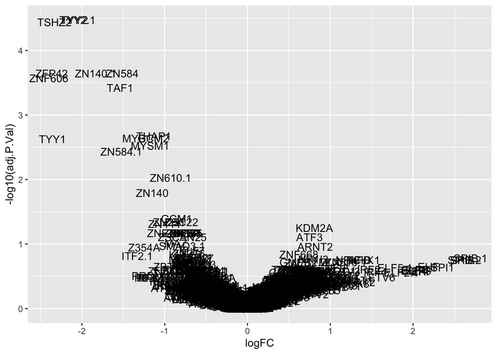

```r
# fit model with sex as main effect and condition as covariate
design <- model.matrix(~sex + condition, data=as.data.frame(colData(dev)))

fit <- eBayes(lmFit(assay(dev, "z"), design))
res <- as.data.frame(topTable(fit, coef=2, number = Inf))
res$motif <- row.names(res)
ggplot(res, aes(logFC, -log10(adj.P.Val), label=motif)) + geom_text()
```

On the following heatmap we see the motifs that show the largest differences regarding their accessability in males compared to females.

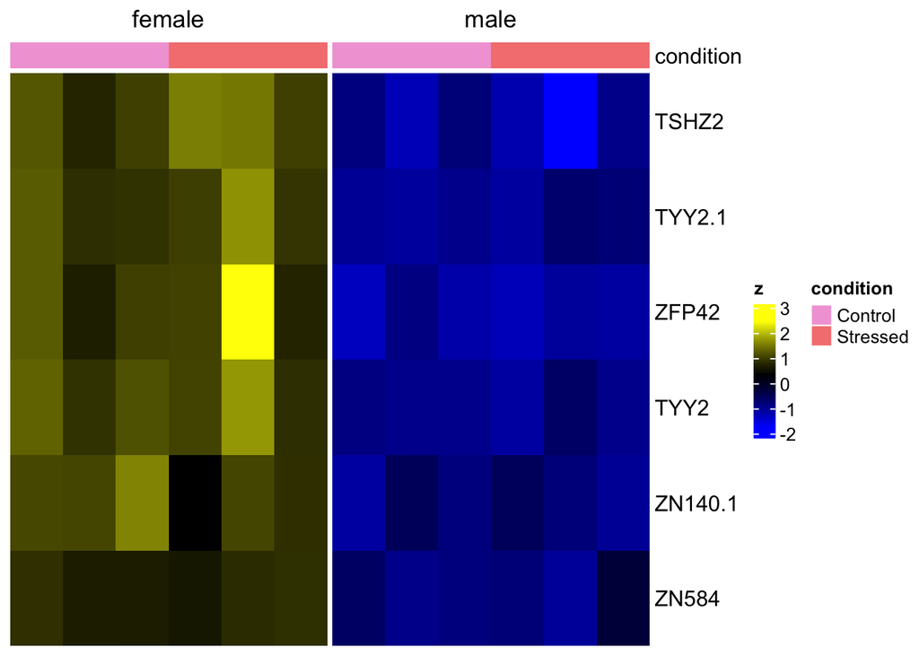

```r
sechm(dev, head(row.names(res)), gaps_at="sex", assayName = "z")
```